#### Name: Anh Do

# Open University Learning Dataset Analytics

## Agenda

- The dataset and the tools use to analyze it
- My method and assumptions
- Process to build ETL, clean, merger and handle the data
- Finding and Conclusion
- Suggested Actions

## The dataset and the tools to analyze it

The dataset contains data about courses, students and their interactions with Virtual Learning Environment (VLE) for seven selected courses (called modules). Presentations of courses start in February and October - they are marked by “B” and “J” respectively. There are total 7 files in the dataset. I will use Jupyter Notebook to analyze the dataset and plot for this dataset.

##### Database Schema

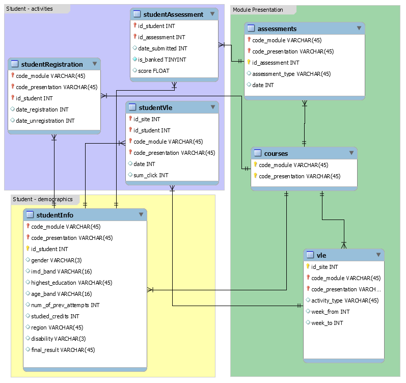

```python
from IPython.display import Image
Image('https://analyse.kmi.open.ac.uk/resources/images/model.png',width = 600, height = 300)
```

## Methods and Assumptions

In order to explore this dataset, this report will list out some opened questions that based on the topic of each table. The answers for these questions will provide insights about the dataset. After that, this report will continue to extend related questions by mergering the tables together, exploring the relationships between relative variables. By doing that, we can consider to build the multiple regression model that affect the result of the student's performance. At the end, we can have insights about the dataset and can suggest some resonable actions to improve the learning environment.

There are some questions we need to know about the platform:

COURSES:

- What course is the longest/shortest?
- How many students enroll in Spring/Fall, which time we have more students?
- Top courses which have highest enrollment?
- How many students drop during the course? What Course have the highest number of withdrawal?
- What assessment types bring the higher results or higher assessment?

STUDENTS:

- How many male/female enroll in total class (in percentage?)
- What top regions student come from?
- What is percentage of student's level of education?
- Age of student?
- What age have higher result?
- How many courses do 1 student enroll?
- How many students are disability?
- Does disability affect their result?
- What is the score distribution?

RELATIONSHIP EXPLORATION

- What factor affect a higher result?

To answer this question, I assume that assessment type, gender, region, imd band, disability, level of education, and age may affect on student's scores.

## Process to build ETL, clean, merger and handle the data

1. Loading the dataset
2. Build some functions to clean and handle missing data
3. Adding year and semester columns to describe the data change by time series
4. Resolve NANs in the dataset by removing or fill with 0 depend on each case
5. Merge necessery tables (ex. Student assessment table and Assessment table) to answer the question by Merge method
6. Explore the dataset by answer the questions

#### Loading the dataset

```python
import pandas as pd
import numpy as np
import matplotlib.pyplot as plt
import seaborn as sns
```

```python
Courses = pd.read_csv("courses.csv")

Assessments = pd.read_csv("assessments.csv")

Vle = pd.read_csv("vle.csv")

Student_info = pd.read_csv("studentInfo.csv")

Student_registration = pd.read_csv("studentRegistration.csv")

Student_assessment = pd.read_csv("studentAssessment.csv")

Student_vle = pd.read_csv("studentVle.csv")
```

#### Build some functions to clean and handle data

```python
# Adding year and semester columns to each table
def addYearAndSes(dataframe):
    # Semester replace
    Semester = {"B": "Fall", "J": "Spring"}

    # add column
    dataframe["Year"] = dataframe["code_presentation"].str[0:4]
    dataframe["Semester"] = dataframe["code_presentation"].str[-1].replace(Semester)
    return dataframe.head(2)
```

```python
# Display basic info
def show_df_info(df):
    print("HEAD:")
    print(df.head(2))
    print("-----------------------------------------------------------------------------------")
    print("SHAPE:")
    print(df.shape)
    print("-----------------------------------------------------------------------------------")
    print("INFO:")
    print(df.info())
    print("-----------------------------------------------------------------------------------")
    print("DESCRIBE:")
    print(df.describe())
    print("-----------------------------------------------------------------------------------")
```

```python
# convert NaNs to some predefined data
def resolveNANs(dataframe):
    # Loop each column
    for columnName in dataframe.columns:
        # Change NAN depend on data type
        if dataframe[columnName].dtype == "object":
            dataframe[columnName] = dataframe[columnName].fillna("Nothing")

        elif dataframe[columnName].dtype == "int64":
            dataframe[columnName] = dataframe[columnName].fillna(0)

        elif dataframe[columnName].dtype == "float64":
            dataframe[columnName] = dataframe[columnName].fillna(0.0)

    return dataframe
```

```python
# Check NaNs
def checkNa(dataframe):
    return dataframe.isna().sum()
```

#### Adding year and semester columns to describe the data change by time series

```python
# Courses dataset
addYearAndSes(Courses)
```

|  | code_module | code_presentation | module_presentation_length | Year | Semester |
| --- | --- | --- | --- | --- | --- |
| 0 | AAA | 2013J | 268 | 2013 | Spring |
| 1 | AAA | 2014J | 269 | 2014 | Spring |

```python
# Assessment dataset
addYearAndSes(Assessments)
```

|  | code_module | code_presentation | id_assessment | assessment_type | date | weight | Year | Semester |
| --- | --- | --- | --- | --- | --- | --- | --- | --- |
| 0 | AAA | 2013J | 1752 | TMA | 19.0 | 10.0 | 2013 | Spring |
| 1 | AAA | 2013J | 1753 | TMA | 54.0 | 20.0 | 2013 | Spring |

```python
# Vle dataset
addYearAndSes(Vle)
```

|  | id_site | code_module | code_presentation | activity_type | week_from | week_to | Year | Semester |
| --- | --- | --- | --- | --- | --- | --- | --- | --- |
| 0 | 546943 | AAA | 2013J | resource | NaN | NaN | 2013 | Spring |
| 1 | 546712 | AAA | 2013J | oucontent | NaN | NaN | 2013 | Spring |

```python
# Student_info dataset
addYearAndSes(Student_info)
```

|  | code_module | code_presentation | id_student | gender | region | highest_education | imd_band | age_band | num_of_prev_attempts | studied_credits | disability | final_result | Year | Semester |
| --- | --- | --- | --- | --- | --- | --- | --- | --- | --- | --- | --- | --- | --- | --- |
| 0 | AAA | 2013J | 11391 | M | East Anglian Region | HE Qualification | 90-100% | 55<= | 0 | 240 | N | Pass | 2013 | Spring |
| 1 | AAA | 2013J | 28400 | F | Scotland | HE Qualification | 20-30% | 35-55 | 0 | 60 | N | Pass | 2013 | Spring |

```python
# Student_registration dataset
addYearAndSes(Student_registration)
```

|  | code_module | code_presentation | id_student | date_registration | date_unregistration | Year | Semester |
| --- | --- | --- | --- | --- | --- | --- | --- |
| 0 | AAA | 2013J | 11391 | -159.0 | NaN | 2013 | Spring |
| 1 | AAA | 2013J | 28400 | -53.0 | NaN | 2013 | Spring |

```python
# Student_vle dataset
addYearAndSes(Student_vle)
```

|  | code_module | code_presentation | id_student | id_site | date | sum_click | Year | Semester |
| --- | --- | --- | --- | --- | --- | --- | --- | --- |
| 0 | AAA | 2013J | 28400 | 546652 | -10 | 4 | 2013 | Spring |
| 1 | AAA | 2013J | 28400 | 546652 | -10 | 1 | 2013 | Spring |

#### Resolve NANs in the dataset by removing or fill with 0 depend on each case

```python
# Check NaN
checkNa(Student_registration)
# There are only 45 NaNs records in date registration in the data, therefore, I remove them in dataset
Student_reg_nonna = Student_registration[Student_registration['date_registration'].notna()]

# We need to keep NaNs date_unregistration is student who complete the courses; therefore, we can keep them in the data
checkNa(Student_reg_nonna)
```

```
code_module                0
code_presentation          0
id_student                 0
date_registration          0
date_unregistration    22515
Year                       0
Semester                   0
dtype: int64
```

```python
# Check NaN
checkNa(Student_assessment)
# There are 173 missing score in total 173,912 records. The missing score is because these student did not submit their assessments.
# I will drop the nan record because it is small amound compared to total records.
Student_assessment_nona = Student_assessment.dropna()
checkNa(Student_assessment_nona)
```

```
id_assessment     0
id_student        0
date_submitted    0
is_banked         0
score             0
dtype: int64
```

#### Merge necessery tables

```python
# Merge Student assessment and assessment score
type_score = Student_assessment_nona.merge(Assessments, on = 'id_assessment', how = 'left')
```

### Explore the dataset by answer the questions

##### Courses:

##### What course is the longest/shortest?

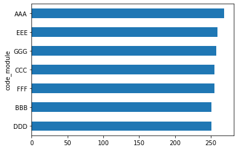

```python
Course_length= Courses.groupby("code_module").module_presentation_length.mean().sort_values(ascending = False).reset_index()
Course_length.sort_values(by = "module_presentation_length").plot(x= "code_module",kind = 'barh', legend = None)
plt.show()
```

##### How many students enroll in Spring/Fall semester, which time we have more students?

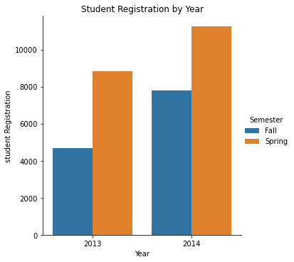

```python
Student_by_ses = Student_reg_nonna.groupby(["Year","Semester"]).id_student.count()

a = sns.catplot(x = "Year", y = "id_student", hue = "Semester", data = Student_by_ses.reset_index(), kind= "bar")
a.set(title = "Student Registration by Year",
      xlabel = "Year",
     ylabel = "student Registration")
plt.show()
```

##### Top courses which have highest enrollment?

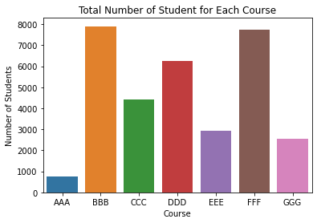

```python
# Top enrollment by course
sns.countplot(Student_reg_nonna.code_module)
plt.title("Total Number of Student for Each Course")
plt.xlabel("Course")
plt.ylabel("Number of Students")
plt.xticks(rotation = 0)
plt.show()
```

BBB and FFF are top 2 courses which have highest enrollments with almost 8,000 enrollments. Moreover, it also provide that AAA and GGG have the lowest enrollments.

##### How many students drop during the course? What Course have the highest number of withdrawal?

```python
# Check unique value in final result
Student_info.final_result.unique()
```

```
array(['Pass', 'Withdrawn', 'Fail', 'Distinction'], dtype=object)
```

```python
# Count number of students in each kind of result.
Result_count = Student_info.final_result.value_counts(ascending= False)
# Total student
print(str("Total number of student is: ").title() + str(Result_count.sum()) + " students.")
```

```
Total Number Of Student Is: 32593 students.
```

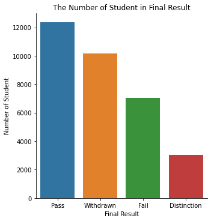

```python
b = sns.catplot(x = "index", y = "final_result",
                data = Result_count.reset_index(), kind= "bar")
b.set(title = "The Number of Student in Final Result",
      xlabel = "Final Result",
     ylabel = "Number of Student")
plt.show()
```

The result shows us that there are more than 10,000 students in 32,593 total withdraw their courses. it means that about 1/3 of total students dropping classes. We also can see that the number of Fail result is very high with about 7,000 students. Then, we need to know which course have highest number of Fail and Withdraw result.

##### What Course have the highest number of Fail and withdrawal?

```python
course_result = Student_info.groupby(["code_module", "final_result"]).id_student.count()
course_result = course_result.loc[:,["Fail", "Withdrawn"]].unstack()
```

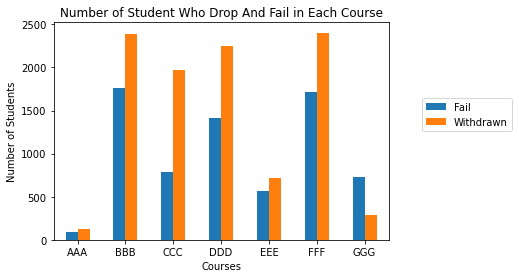

```python
course_result.plot(kind = "bar")
plt.title("Number of Student Who Drop And Fail in Each Course")
plt.xlabel("Courses")
plt.ylabel("Number of Students")
plt.legend(loc=(1.1, 0.5))
plt.xticks(rotation = 0)
plt.show()
```

##### What assessment types bring the higher results or higher assessment?

```python
type_score.head(3)
```

|  | id_assessment | id_student | date_submitted | is_banked | score | code_module | code_presentation | assessment_type | date | weight | Year | Semester |
| --- | --- | --- | --- | --- | --- | --- | --- | --- | --- | --- | --- | --- |
| 0 | 1752 | 11391 | 18 | 0 | 78.0 | AAA | 2013J | TMA | 19.0 | 10.0 | 2013 | Spring |
| 1 | 1752 | 28400 | 22 | 0 | 70.0 | AAA | 2013J | TMA | 19.0 | 10.0 | 2013 | Spring |
| 2 | 1752 | 31604 | 17 | 0 | 72.0 | AAA | 2013J | TMA | 19.0 | 10.0 | 2013 | Spring |

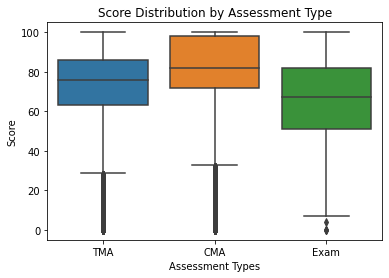

```python
sns.boxplot(x = 'assessment_type', y = 'score', data = type_score)
plt.title("Score Distribution by Assessment Type")
plt.xlabel("Assessment Types")
plt.ylabel("Score")
plt.show()
```

The boxplot shows that Computer Marked test have average of highest score than other test. In that case, Final exam is the harderst exam which have only average point of 65.

##### STUDENTS:

##### How many male/female enroll in total class (in percentage?)

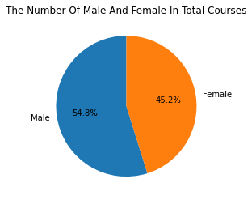

```python
Gender_count = Student_info.gender.value_counts(ascending= False)
plt.pie(Student_info.gender.value_counts(), labels=['Male', 'Female'],autopct='%1.1f%%',
        startangle=90)
plt.title(str('The Number of Male and Female in Total Courses').title())
plt.show()
```

The pie chart shows that the number Male students is higher than Female student almost 10%.

##### What regions student come from?

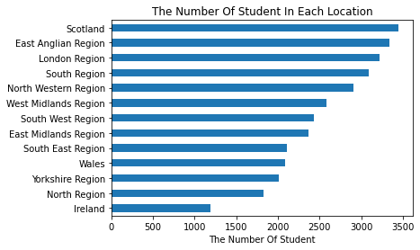

```python
region_count = Student_info.region.value_counts(ascending= False)

Student_info.region.value_counts(ascending= True).plot(kind = 'barh')
plt.title(str('The Number of Student in Each Location').title())
plt.xlabel(str('The number of student').title())
plt.show()
```

The graph shows that top 5 regions that have highest number of student are Scotland (10.5%), East Anglian (10.2%), London Region (9.8%), South Region (9.4%), and North Western (8.9%). These region almost keep 50% total students.

##### What is percentage of student's level of education?

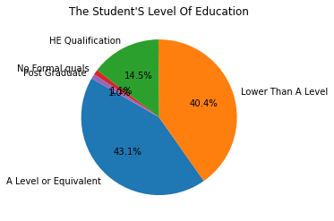

```python
edu_level_count = Student_info.highest_education.value_counts(ascending= False)

edu_label = ['A Level or Equivalent','Lower Than A Level', 'HE Qualification', 'No Formal quals', 'Post Graduate']
plt.pie(Student_info.highest_education.value_counts(), labels= edu_label ,autopct='%1.1f%%',
        startangle=150)
plt.title(str("The student's level of education").title())
plt.show()
```

Most of student come to our VLE are lower A level or equal A level. Both of section combine together bring 83% of students (about 27,100 students) for learning environment. Therefore, we should create proper course content which bring more benefits for these sections.

##### Age of student?

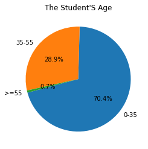

```python
age_count = Student_info.age_band.value_counts(ascending= False)

age_label = ['0-35','35-55', '>=55']
plt.pie(Student_info.age_band.value_counts(), labels= age_label ,autopct='%1.1f%%',
        startangle=195)
plt.title(str("The student's Age").title())
plt.show()
```

About 70% of platform students are young people use virtual platform to learn more knowledge. 29% student is from 35 -55 years old. They may be want to update their knowledge for their career or use them to learn new content.

##### What age/gender have higher result?

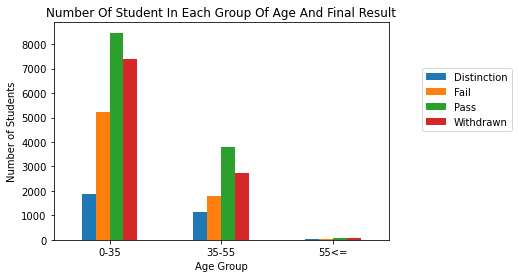

```python
age_res = pd.crosstab(Student_info.age_band,Student_info.final_result)

age_res.plot(kind = 'bar')
plt.title("Number Of Student In Each Group Of Age And Final Result")
plt.xlabel("Age Group")
plt.ylabel("Number of Students")
plt.legend(loc=(1.1, 0.5))
plt.xticks(rotation = 0)
plt.show()
```

We can see that the percentage of final result for each age group is quite similar with averge of 38% students pass the exam. However, people under 35 years old have a lowest ratio of Pass student with about 37%. People who have higher age tend to have better result in their exam with 42% pass student equal or higher than 55 years old.

##### How many courses do 1 student enroll?

```python
course_per_student = Student_reg_nonna.groupby('id_student').code_module.count().reset_index().groupby('code_module').count()
```

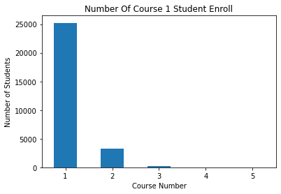

```python
course_per_student.plot(kind = 'bar', legend = None)
plt.title("Number Of Course 1 Student Enroll")
plt.xlabel("Course Number")
plt.ylabel("Number of Students")
plt.xticks(rotation = 0)
plt.show()
```

25,230 students (77%) enroll only 1 course in the platform. About 10% of student choose one more course in the platform. This is quite low compare to total 7 offered courses. The university should attract students to enroll more class in platform.

##### How many students are disability?

```python
disability_count = Student_info.disability.value_counts(ascending= False)
```

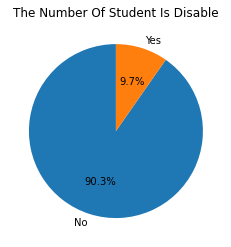

```python
disability_label = ['No', 'Yes']
plt.pie(Student_info.disability.value_counts(), labels= disability_label ,autopct='%1.1f%%',
        startangle=90)
plt.title(str("The Number of Student Is Disable").title())
plt.show()
```

There is around 10% of student is disable. We will check that does disability affect their final result?

##### Does disability affect their result?

```python
print(pd.crosstab(Student_info.disability, Student_info.final_result, margins = True, normalize= True))

# Number of student who are disable and pass the course
num_pass_dis = disable_result.loc['Y','Pass'] / disable_result.loc['Y','All']
print("\nThe percentage of student who are disable and pass the course: " + str(round(num_pass_dis*100,2)) + '%')

# Number of student who are not disable and pass the course
num_pass_non = disable_result.loc['N','Pass'] / disable_result.loc['N','All']
print("\nThe percentage of student who are normal and pass the course: " + str(round(num_pass_non*100,2)) + '%')
```

```
final_result  Distinction      Fail      Pass  Withdrawn       All
disability
N                0.085939  0.194520  0.349063   0.273402  0.902924
Y                0.006842  0.021845  0.030191   0.038198  0.097076
All              0.092781  0.216365  0.379253   0.311601  1.000000

The percentage of student who are disable and pass the course: 31.1%

The percentage of student who are normal and pass the course: 38.66%
```

We can see that there is small difference in final_result ratio between 2 groups. Students who is disable have 7% lower in final result ratio compared to who is not. It means that they need more help from instruction to have better result.

##### Score Distribution

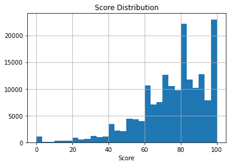

```python
Student_assessment_nona.score.hist(bins = 30)
plt.title("Score Distribution")
plt.xlabel("Score")
plt.show()
```

The histogram shows that there are very high number of students have around 80 and 100 points in their assessments. Moreover, most of student get higher than 60 points. In the previous question, we also find that around 38% in total student pass in final result.

### Relationship Exploration

#### What factor affect a higher result?

```python
import statsmodels.formula.api as smf
```

##### Change data type

```python
Student_info[['gender', 'disability']] = Student_info[['gender', 'disability']].astype('bool')
Student_info[['region', 'highest_education', 'age_band', 'imd_band']] = Student_info[['region', 'highest_education', 'age_band', 'imd_band']].astype('category')
```

###### Merge student score with student info and assessment type

```python
Student_assessment_nona_subset = Student_assessment_nona[['id_assessment', 'id_student','score']]
Student_info_subset = Student_info[['id_student','gender', 'disability','region', 'highest_education', 'age_band']]
Assessments_subset = Assessments[['id_assessment','assessment_type']]
```

```python
# Merge assessment type to student assessment
Merge_df = Student_assessment_nona_subset.merge(Assessments_subset, how = 'left', on = 'id_assessment').\
merge(Student_info_subset, on = 'id_student', how = 'left')
Merge_df.head(3)
```

|  | id_assessment | id_student | score | assessment_type | gender | disability | region | highest_education | age_band |
| --- | --- | --- | --- | --- | --- | --- | --- | --- | --- |
| 0 | 1752 | 11391 | 78.0 | TMA | True | True | East Anglian Region | HE Qualification | 55<= |
| 1 | 1752 | 28400 | 70.0 | TMA | True | True | Scotland | HE Qualification | 35-55 |
| 2 | 1752 | 31604 | 72.0 | TMA | True | True | South East Region | A Level or Equivalent | 35-55 |

```python
# Make multiple regression model all factor that may affect student's score
formula = 'score ~ C(assessment_type) + gender + disability + C(highest_education) + C(age_band)'
rlm = smf.ols(formula, data = Merge_df).fit()
rlm.summary()
```

OLS Regression Results

| Dep. Variable: | score | R-squared: | 0.058 |
| --- | --- | --- | --- |
| Model: | OLS | Adj. R-squared: | 0.058 |
| Method: | Least Squares | F-statistic: | 1590. |
| Date: | Wed, 09 Jun 2021 | Prob (F-statistic): | 0.00 |
| Time: | 02:00:00 | Log-Likelihood: | -8.9833e+05 |
| No. Observations: | 207092 | AIC: | 1.797e+06 |
| Df Residuals: | 207083 | BIC: | 1.797e+06 |
| Df Model: | 8 |  |  |
| Covariance Type: | nonrobust |  |  |

|  | coef | std err | t | P>\|t\| | [0.025 | 0.975] |
| --- | --- | --- | --- | --- | --- | --- |
| Intercept | 26.7034 | 0.027 | 981.787 | 0.000 | 26.650 | 26.757 |
| C(assessment_type)[T.Exam] | -14.8417 | 0.236 | -62.877 | 0.000 | -15.304 | -14.379 |
| C(assessment_type)[T.TMA] | -7.5982 | 0.084 | -90.368 | 0.000 | -7.763 | -7.433 |
| gender[T.True] | 26.7034 | 0.027 | 981.787 | 0.000 | 26.650 | 26.757 |
| disability[T.True] | 26.7034 | 0.027 | 981.787 | 0.000 | 26.650 | 26.757 |
| C(highest_education)[T.HE Qualification] | 1.3610 | 0.119 | 11.437 | 0.000 | 1.128 | 1.594 |
| C(highest_education)[T.Lower Than A Level] | -2.5115 | 0.091 | -27.559 | 0.000 | -2.690 | -2.333 |
| C(highest_education)[T.No Formal quals] | -5.3001 | 0.464 | -11.418 | 0.000 | -6.210 | -4.390 |
| C(highest_education)[T.Post Graduate Qualification] | 6.8080 | 0.363 | 18.747 | 0.000 | 6.096 | 7.520 |
| C(age_band)[T.35-55] | 2.2796 | 0.090 | 25.277 | 0.000 | 2.103 | 2.456 |
| C(age_band)[T.55<=] | 4.1877 | 0.479 | 8.749 | 0.000 | 3.249 | 5.126 |

| Omnibus: | 36647.621 | Durbin-Watson: | 1.415 |
| --- | --- | --- | --- |
| Prob(Omnibus): | 0.000 | Jarque-Bera (JB): | 66281.439 |
| Skew: | -1.127 | Prob(JB): | 0.00 |
| Kurtosis: | 4.613 | Cond. No. | 2.59e+18 |

Warnings:  
[1] Standard Errors assume that the covariance matrix of the errors is correctly specified.  
[2] The smallest eigenvalue is 1.11e-31. This might indicate that there are  
strong multicollinearity problems or that the design matrix is singular.

##### Is Student's performance affected by the length of the course?

```python
score_date = Student_assessment.sort_values(by = 'date_submitted')
```

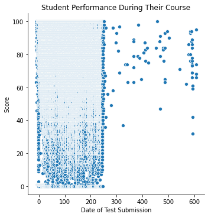

```python
sns.relplot(x = 'date_submitted', y = 'score', data = score_date, kind = 'scatter')
plt.title('Student Performance During Their Course')
plt.xlabel('Date of Test Submission')
plt.ylabel('Score')
plt.show()
```

It seems like there is no relationship between student's score and the length of the course, because the score is distributed radomly through the time of the course.

### Finding and Conclusion

COURSES:

STUDENTS:

- The number Male students is higher than Female student almost 10%. Students accounts for 54.8% for Mal and 45.2% for Female
- Top 5 regions that have highest number of student are Scotland (10.5%), East Anglian (10.2%), London Region (9.8%), South Region (9.4%), and North Western (8.9%). These region almost keep 50% total students.
- Most of student come to our VLE are lower A level or equal A level. Both of section combine together bring 83% of students (about 27,100 students) for learning environment. Therefore, we should create proper course content which bring more benefits for these sections.
- About 70% of platform students are young people use virtual platform to learn more knowledge. 29% student is from 35 -55 years old. They may be want to update their knowledge for their career or use them to learn new content.
- The percentage of final result for each age group is quite similar with averge of 38% students pass the exam. However, people under 35 years old have a lowest ratio of Pass student with about 37%. People who have higher age tend to have better result in their exam with 42% pass student equal or higher than 55 years old.
- 25,230 students (77%) enroll only 1 course in the platform. About 10% of student choose one more course in the platform. This is quite low compare to total 7 offered courses. The university should attract students to enroll more class in platform.
- There is around 10% of student is disable. We will check that does disability affect their final result?
- We find that there is small difference in final_result ratio between 2 groups. Students who is disable have 7% lower in final result ratio compared to who is not. It means that they need more help from instruction to have better result.
- There are very high number of students have around 80 and 100 points in their assessments. Moreover, most of student get higher than 60 points. In the previous question, we also find that around 38% in total student pass in final result.

RELATIONSHIP EXPLORATION

- Is Student's performance affected by the length of the course?

There is no relationship between student's score and the length of the course, because the score is distributed radomly through the time of the course.

### Suggested Action

I think that there are some things the university can do to improve the platform:

1 . Improve the content of course to attract more students in different age band, and region. We also see that most of student just use the platform for only 1 course, we need to build up the courses into a program to help them improve all skills in generally.

2 . We can analyze more about preferences on top regions to bring more benefits on these students.

3 . The disability also have a impact on student's result. Therefore, we need to find useful tools to help them to catch up with other students.